# Data analysis notebook (messy but complete version), Meta-Analyses in tDCS - Motor Learning Research

**Load packages and dataset**

```r
library("readxl")
library("tidyverse")
library("metafor")
library("MAd")
library("meta")
library("dmetar") # not available on CRAN as of September 2021, pulled from GitHub
```

If you want to run the code outside of the project folder and without the renv.lock file (from the [`renv`](https://rstudio.github.io/renv/articles/renv.html) package), loading the packages using the package [`groundhog`](https://groundhogr.com/) would ensure the code’s long term reproducibility:

```r
# install.packages("groundhog")
# library(groundhog)
# pkgs <- c("readxl", "tidyverse", "metafor", "MAd", "meta")
# date = "2021-12-19"
# groundhog.library(pkgs, date)
```

# 1 Meta-analysis 1

### 1.0.1 Load dataset & preprocess data - FINAL

```r
df <- read_excel("data_thesis/Data_ps_raw.xlsx", sheet = "MA1")


# remove characters marking SEs, upper bounds of SE bars, or upper bounds of CIs, to convert to SDs
df[] <- lapply(df, gsub, pattern = '/', replacement = '', fixed = TRUE)
df[] <- lapply(df, gsub, pattern = '*', replacement = '', fixed = TRUE)

# make values numeric
df <- df %>% mutate_at(vars(starts_with('sd')), as.numeric)
df <- df %>% mutate_at(vars(starts_with('mt')), as.numeric)
df <- df %>% mutate_at(vars(starts_with('mc')), as.numeric)
df <- df %>% mutate_at(vars(starts_with('smd')), as.numeric)
df <- df %>% mutate_at(vars(starts_with('n')), as.numeric)
df <- df %>% mutate_at(vars(starts_with('ci')), as.numeric)
df <- df %>% mutate_at(vars(starts_with('p_')), as.numeric)
df <- df %>% mutate_at(vars(starts_with('t_')), as.numeric)
df <- df %>% mutate_at(vars(starts_with('F_')), as.numeric)
df <- df %>% mutate_at(vars(starts_with('se')), as.numeric)

# Convert SEs to SDs
df[3, "sdc_ps.1"] <- df[3, "sdc_ps.1"] * sqrt(10)
df[3, "sdt_ps.1"] <- df[3, "sdt_ps.1"] * sqrt(10)

# Convert upper bounds of SE bars extracted from figures to SDs
df[1, "sdc_ps.1"] <- (df[1, "sdc_ps.1"] - df[1, "mc_ps.1"]) * sqrt(7)
df[1, "sdt_ps.1"] <- (df[1, "sdt_ps.1"] - df[1, "mt_ps.1"]) * sqrt(7)

df[2, "sdc_ps.1"] <- (df[2, "sdc_ps.1"] - df[2, "mc_ps.1"]) * sqrt(9)
df[2, "sdt_ps.1"] <- (df[2, "sdt_ps.1"] - df[2, "mt_ps.1"]) * sqrt(9)

df[8, "sdc_ps.1"] <- (df[8, "sdc_ps.1"] - df[8, "mc_ps.1"]) * sqrt(13)
df[8, "sdt_ps.1"] <- (df[8, "sdt_ps.1"] - df[8, "mt_ps.1"]) * sqrt(14)

df[9, "sdc_ps.1"] <- (df[9, "sdc_ps.1"] - df[9, "mc_ps.1"]) * sqrt(13)
df[9, "sdt_ps.1"] <- (df[9, "sdt_ps.1"] - df[9, "mt_ps.1"]) * sqrt(13)

df[10, "sdc_ps.1"] <- (df[10, "sdc_ps.1"] - df[10, "mc_ps.1"]) * sqrt(7)
df[10, "sdt_ps.1"] <- (df[10, "sdt_ps.1"] - df[10, "mt_ps.1"]) * sqrt(6)

df[11, "sdc_ps.1"] <- (df[11, "sdc_ps.1"] - df[11, "mc_ps.1"]) * sqrt(7)
df[11, "sdt_ps.1"] <- (df[11, "sdt_ps.1"] - df[11, "mt_ps.1"]) * sqrt(5)

# Convert upper bounds of SD bars extracted from figures to SDs
df[4, "sdc_ps.1"] <- (df[4, "sdc_ps.1"] - df[4, "mc_ps.1"])
df[4, "sdt_ps.1"] <- (df[4, "sdt_ps.1"] - df[4, "mt_ps.1"])

# Convert upper bounds of CI bars extracted from figures to SDs
df[20, "sdc_ps.1"] <- (df[20, "sdc_ps.1"] - df[20, "mc_ps.1"]) * sqrt(45) / 1.96
df[20, "sdt_ps.1"] <- (df[20, "sdt_ps.1"] - df[20, "mt_ps.1"]) * sqrt(45) / 1.96
```

```r
# average group sample size
mean((df$nc_ma + df$nt_ma) / 2)
```

```
## [1] 12.97619
```

### 1.0.2 Reproduce primary SMDs

3 meta-analytic models were fit:

1. MA1: Using the SMDs reproduced strictly following information given in the meta-analysis or a standard procedure apparently adopted for at least 2 other primary SMDs (e.g., Cohen’s $d$ of tDCS vs. Sham at post intervention).
2. MA2: Using the SMDs reproduced strictly following information given in the meta-analysis or a standard procedure apparently adopted for at least 2 other primary SMDs + SMDs that could be successfully reproduced (i.e., reproduced SMD = reported SMD) following a procedure which **either** does not entirely correspond to what the meta-analysts report having adopted **or** does not (necessarily) produce an SMD that is comparable to what would result from following the procedure apparently adopted for at least 2 other primary SMDs
3. MA3: Using the reported SMDs only (reproduce fitting the MA model using values reported in the MA only)

#### 1.0.2.1 Between-groups studies which reported sample sizes, means and SDs (SEs/CIs)

```r
df <- compute_ds(nt_ps, mt_ps.1, sdt_ps.1, nc_ps, mc_ps.1, sdc_ps.1, data = df, denom = "pooled.sd")
df$d <- abs(df$d)

# relocate to facilitate inspection
df <- df %>% relocate(c(id_comparison, d, smd_ma), .after = dv_ps)
```

The SMDs that could not be reproduced or approximated (those based on values from figures can only be approximated due to variations in how values were extracted from figures): (4/17 comparisons from between-groups studies). Reproduced SMDs 16, 17, 18, and 20 deviate from the reported ones beyond what would be expected as a result of rounding or differences in how values were extracted from figures. For SMDs 16 and 20, other values could have been used:

For SMD 16, another set of means and SDs could have been used:

```r
compute_ds(nt_ps, mt_ps.2, sdt_ps.2, nc_ps, mc_ps.2, sdc_ps.2, data = df, denom = "pooled.sd")$d[[16]]
```

```
## [1] 1.428169
```

Reproduces reported SMD successfully.

SMD 20 had corresponding $p$-value:

```r
p_to_d1(df$p_ps[[20]], df$nt_ps[[20]], df$nc_ps[[20]])[1]
```

```
## [1] 0.6715506
```

```r
p_to_d2(df$p_ps[[20]], df$nt_ps[[20]], df$nc_ps[[20]])[1]
```

```
## [1] 0.7177413
```

The SMD based on the two tailed $p$ value successfully reproduces the reported SMD.

#### 1.0.2.2 Crossover studies which reported sample sizes, means and SDs (SEs/CIs)

Since the meta-analysts listed the sample size of both the treatment and control group as = $N$ = the number of participants, I use N as the sample size of both groups even though there aren’t two groups:

```r
df2 <- df %>% filter(is.na(nc_ps))
df2 <- compute_ds(n_ps, mt_ps.1, sdt_ps.1, n_ps, mc_ps.1, sdc_ps.1, data = df2, denom = "pooled.sd")
```

Reproduced SMDs 12, 13, 21 deviate from the reported ones beyond what would be expected as a result of rounding or differences in how values were extracted from figures. For SMDs 12 and 13, other values could have been used: SMDs 12 and 13 had another set of means and SDs:

```r
compute_ds(n_ps, mt_ps.2, sdt_ps.2, n_ps, mc_ps.2, sdc_ps.2, data = df, denom = "pooled.sd")$d[[12]]
```

```
## [1] 1.632313
```

```r
compute_ds(n_ps, mt_ps.2, sdt_ps.2, n_ps, mc_ps.2, sdc_ps.2, data = df, denom = "pooled.sd")$d[[13]]
```

```
## [1] 1.605791
```

Still not reproducible. SMD 13 does reproduce the Cohen’s $d$ reported in the primary study, though.

### 1.0.3 Overview of SMDs post double checking irreproducible SMDs

Data extraction was correct for all SMDs and no further data were extracted (see data sheets column “comments” for sources of data).

### 1.0.4 Collate reproduced primary SMDs for MA model 1

```r
# SMDs which were successfully reproduced using the first set of means and SDs, in accordance with information in MA
df$smd_re1 <- compute_ds(nt_ps, mt_ps.1, sdt_ps.1, nc_ps, mc_ps.1, sdc_ps.1, data = df, denom = "pooled.sd")$d

df$smd_re1[[2]] <- compute_ds(n_ps, mt_ps.1, sdt_ps.1, n_ps, mc_ps.1, sdc_ps.1, data = df, denom = "pooled.sd")$d[[2]]

# SMDs which could not be reproduced using the first set of means and SDs, in accordance with information in MA
df$smd_re1[[21]] <- compute_ds(n_ps, mt_ps.1, sdt_ps.1, n_ps, mc_ps.1, sdc_ps.1, data = df, denom = "pooled.sd")$d[[21]]

# SMDs which were successfully reproduced using values that either do not quite correspond to the information given in the MA or the standard method adopted for the other SMDs

df$smd_re1[[19]] <- NA

df$smd_re1[[20]] <- NA

# SMDs which could not be reproduced using values that either do not quite correspond to the information given in the MA or the standard method adopted for the other SMDs
df$smd_re1[[12]] <- NA

df$smd_re1[[13]] <- NA

# make numeric and positive
df$smd_re1 <- df$smd_re1 %>% as.numeric() %>% abs()

# relocate to check if everything's fine
df <- df %>% relocate(c(id_comparison, smd_re1, smd_ma), .after = dv_ps)
```

### 1.0.5 Collate reproduced primary SMDs for MA model 2

```r
# SMDs which were successfully reproduced using the first set of means and SDs, in accordance with information in MA
df$smd_re2 <- compute_ds(nt_ps, mt_ps.1, sdt_ps.1, nc_ps, mc_ps.1, sdc_ps.1, data = df, denom = "pooled.sd")$d

df$smd_re2[[2]] <- compute_ds(n_ps, mt_ps.1, sdt_ps.1, n_ps, mc_ps.1, sdc_ps.1, data = df, denom = "pooled.sd")$d[[2]]

# SMDs which could not be reproduced using the first set of means and SDs, in accordance with information in MA
df$smd_re2[[21]] <- compute_ds(n_ps, mt_ps.1, sdt_ps.1, n_ps, mc_ps.1, sdc_ps.1, data = df, denom = "pooled.sd")$d[[21]]

# SMDs which were successfully reproduced using values that either do not quite correspond to the information given in the MA or the standard method adopted for the other SMDs
df$smd_re2[[16]] <- compute_ds(nt_ps, mt_ps.2, sdt_ps.2, nc_ps, mc_ps.2, sdc_ps.2, data = df, denom = "pooled.sd")$d[[16]]

df$smd_re2[[19]] <- compute_ds(nt_ps, mt_ps.1, sdt_ps.1, nc_ps, mc_ps.1, sdc_ps.1, data = df, denom = "pooled.sd")$d[[19]]

df$smd_re2[[20]] <- p_to_d2(df$p_ps[[20]], df$nt_ps[[20]], df$nc_ps[[20]])[1]

# SMDs which could not be reproduced using values that either do not quite correspond to the information given in the MA or the standard method adopted for the other SMDs
df$smd_re2[[12]] <- compute_ds(n_ps, mt_ps.1, sdt_ps.1, n_ps, mc_ps.1, sdc_ps.1, data = df, denom = "pooled.sd")$d[[12]]

df$smd_re2[[13]] <- compute_ds(n_ps, mt_ps.1, sdt_ps.1, n_ps, mc_ps.1, sdc_ps.1, data = df, denom = "pooled.sd")$d[[13]]

# make numeric and positive
df$smd_re2 <- df$smd_re2 %>% as.numeric() %>% abs()

# relocate to check if everything's fine
df <- df %>% relocate(smd_re2, .after = smd_re1)
```

### 1.0.6 Proportion of successfully reproduced primary SMDs strictly following information given in the MA

#### 1.0.6.1 reproducible to the second decimal place

```r
df <- transform(df, rep_1_sec_dec = ifelse(round(smd_re1, digits = 2) == smd_ma, 1, 0))
sum(df$irrep_1_sec_dec, na.rm = TRUE)
```

```
## [1] 0
```

```r
sum(df$irrep_1_sec_dec, na.rm = TRUE)/21 * 100
```

```
## [1] 0
```

#### 1.0.6.2 reproducible to the first decimal place

```r
df <- transform(df, rep_1_fir_dec = ifelse(round(smd_re1, digits = 1) == round(smd_ma, digits = 1), 1, 0))
sum(df$rep_1_fir_dec, na.rm = TRUE)
```

```
## [1] 11
```

```r
sum(df$rep_1_fir_dec, na.rm = TRUE)/21 * 100
```

```
## [1] 52.38095
```

### 1.0.7 Proportion of successfully reproduced primary SMDs brute force

#### 1.0.7.1 reproducible to the second decimal place

```r
df <- transform(df, rep_2_sec_dec = ifelse(round(smd_re2, digits = 2) == smd_ma, 1, 0))
sum(df$rep_2_sec_dec, na.rm = TRUE)
```

```
## [1] 9
```

```r
sum(df$rep_2_sec_dec, na.rm = TRUE)/21 * 100
```

```
## [1] 42.85714
```

#### 1.0.7.2 reproducible to the first decimal place

```r
df <- transform(df, rep_2_fir_dec = ifelse(round(smd_re2, digits = 1) == round(smd_ma, digits = 1), 1, 0))
sum(df$rep_2_fir_dec, na.rm = TRUE)
```

```
## [1] 13
```

```r
sum(df$rep_2_fir_dec, na.rm = TRUE)/21 * 100
```

```
## [1] 61.90476
```

```r
df <- df %>% relocate(c(id_comparison, rep_1_sec_dec, rep_2_sec_dec, rep_1_fir_dec, rep_2_fir_dec, smd_re1, smd_re2, smd_ma), .after = id_ps)
```

### 1.0.8 Reproduce variances of the primary SMDs for MA model 1

`MAd`’s `compute_ds()` and `p_to_d1` functions automatically calculate the corresponding sampling/sampling variances. In cases where not enough data were available, the square of the standard error extracted from the funnel plot in the MA will be used.

```r
# SMDs which were successfully reproduced using the first set of means and SDs, in accordance with information in MA
df$v_re1 <- compute_ds(nt_ps, mt_ps.1, sdt_ps.1, nc_ps, mc_ps.1, sdc_ps.1, data = df, denom = "pooled.sd")$var.d

df$v_re1[[2]] <- compute_ds(n_ps, mt_ps.1, sdt_ps.1, n_ps, mc_ps.1, sdc_ps.1, data = df, denom = "pooled.sd")$var.d[[2]]

# SMDs which could not be reproduced using the first set of means and SDs, in accordance with information in MA
df$v_re1[[21]] <- compute_ds(n_ps, mt_ps.1, sdt_ps.1, n_ps, mc_ps.1, sdc_ps.1, data = df, denom = "pooled.sd")$var.d[[21]]

# SMDs which were successfully reproduced using values that either do not quite correspond to the information given in the MA or the standard method adopted for the other SMDs
# df$v_re1[[16]] <- NA

df$v_re1[[19]] <- NA

df$v_re1[[20]] <- NA

# SMDs which could not be reproduced using values that either do not quite correspond to the information given in the MA or the standard method adopted for the other SMDs
df$v_re1[[12]] <- NA

df$v_re1[[13]] <- NA

# make numeric
df$v_re1 <- as.numeric(df$v_re1)

# relocate to check if everything's fine
df$v_ma <- df$se_ma^2
df <- df %>% relocate(c(id_comparison, v_re1, v_ma), .after = dv_ps)
```

### 1.0.9 Reproduce variances of the primary SMDs for MA model 2

```r
# SMDs which were successfully reproduced using the first set of means and SDs, in accordance with information in MA
df$v_re2 <- compute_ds(nt_ps, mt_ps.1, sdt_ps.1, nc_ps, mc_ps.1, sdc_ps.1, data = df, denom = "pooled.sd")$var.d

df$v_re2[[2]] <- compute_ds(n_ps, mt_ps.1, sdt_ps.1, n_ps, mc_ps.1, sdc_ps.1, data = df, denom = "pooled.sd")$var.d[[2]]

# SMDs which could not be reproduced using the first set of means and SDs, in accordance with information in MA
df$v_re2[[21]] <- compute_ds(n_ps, mt_ps.1, sdt_ps.1, n_ps, mc_ps.1, sdc_ps.1, data = df, denom = "pooled.sd")$var.d[[21]]

# SMDs which were successfully reproduced using values that either do not quite correspond to the information given in the MA or the standard method adopted for the other SMDs
df$v_re2[[16]] <- compute_ds(nt_ps, mt_ps.2, sdt_ps.2, nc_ps, mc_ps.2, sdc_ps.2, data = df, denom = "pooled.sd")$var.d[[16]]

df$v_re2[[19]] <- compute_ds(nt_ps, mt_ps.1, sdt_ps.1, nc_ps, mc_ps.1, sdc_ps.1, data = df, denom = "pooled.sd")$var.d[[19]]

df$v_re2[[20]] <- p_to_d2(df$p_ps[[20]], df$nt_ps[[20]], df$nc_ps[[20]])[2]

# SMDs which could not be reproduced using values that either do not quite correspond to the information given in the MA or the standard method adopted for the other SMDs
df$v_re2[[12]] <- compute_ds(n_ps, mt_ps.1, sdt_ps.1, n_ps, mc_ps.1, sdc_ps.1, data = df, denom = "pooled.sd")$var.d[[12]]

df$v_re2[[13]] <- df$smd_re2[[13]] <- compute_ds(n_ps, mt_ps.1, sdt_ps.1, n_ps, mc_ps.1, sdc_ps.1, data = df, denom = "pooled.sd")$var.d[[13]]


# make numeric
df$v_re2 <- as.numeric(df$v_re2)

# relocate to check if everything's fine
df$v_ma <- df$se_ma^2
df <- df %>% relocate(c(id_comparison, v_re2, v_ma), .after = dv_ps)
```

### 1.0.10 Reproduce the pooled SMD

#### 1.0.10.1 MA model 1

```r
ma1 <- metagen(TE = smd_re1,
              seTE = sqrt(v_re1),
              studlab = id_comparison,
              data = df,
              sm = "SMD",
              fixed = FALSE,
              random = TRUE, # a random effects MA
              method.tau = "DL", # DerSimonian-Laird estimator
                 )
windowsFonts(A = windowsFont("Times New Roman"))

png("figures/fig3_mam1.png", units = "in", width = 7.2, height = 6, res = 300)
forest.meta(ma1,
           fontfamily = "A",
           print.tau2 = TRUE,
           leftlabs = c("SMD No.", "d", "SE"))
```

#### 1.0.10.2 MA model 2

```r
ma2 <- metagen(TE = smd_re2,
              seTE = sqrt(v_re2),
              studlab = id_comparison,
              data = df,
              sm = "SMD",
              fixed = FALSE,
              random = TRUE, # a random effects MA
              method.tau = "DL", # DerSimonian-Laird estimator
                 )
png("figures/fig3_mam2.png", units = "in", width = 7.2, height = 6, res = 300)
forest.meta(ma2,
           fontfamily = "A",
           print.tau2 = TRUE,
           leftlabs = c("SMD No.", "d", "SE"))
```

#### 1.0.10.3 MA model 3

```r
ma3 <- metagen(TE = smd_ma,
              seTE = se_ma,
              studlab = id_comparison,
              data = df,
              sm = "SMD",
              fixed = FALSE,
              random = TRUE, # a random effects MA
              method.tau = "DL", # DerSimonian-Laird estimator
                 )
png("figures/fig3_mam3.png", units = "in", width = 7.2, height = 6, res = 300)
forest.meta(ma3,
           fontfamily = "A",
           print.tau2 = TRUE,
           leftlabs = c("SMD No.", "d", "SE"))
```

## 1.1 Publication bias analysis

The analysis in this section mostly follows the tutorial [here](https://bookdown.org/MathiasHarrer/Doing_Meta_Analysis_in_R/pub-bias.html#addressing-pubbias).

### 1.1.1 PET-PEESE

#### 1.1.1.1 Collate the necessary variables

For the PET-PEESE model, the effect sizes (here SMDs), their SEs, their variances, and their inverse-variance weights, are needed.

```r
petpeese <- data.frame(smd = df$smd_ma) # smds
petpeese$v <- df$v_ma # sampling variances (extracted from the figures)
petpeese$se <- df$se_ma # standard errors of SMD estimates
petpeese$w <- 1/petpeese$v # inverse variance weights
```

#### 1.1.1.2 PET (precision-effect test)

```r
pet <- lm(smd ~ se, weights = w, data = petpeese)
summary(pet)$coefficients
```

```
##              Estimate Std. Error   t value  Pr(>|t|)
## (Intercept) 0.3372718  0.2883465 1.1696754 0.2565960
## se          0.6729077  0.7573059 0.8885547 0.3853538
```

#### 1.1.1.3 PEESE (precision-effect estimate with standard error)

```r
peese <- lm(smd ~ v, weights = w, data = petpeese)
summary(peese)$coefficients
```

```
##              Estimate Std. Error   t value   Pr(>|t|)
## (Intercept) 0.4447256  0.1662313 2.6753423 0.01496346
```

### 1.1.2 P-Curve

#### 1.1.2.1 P-Curve

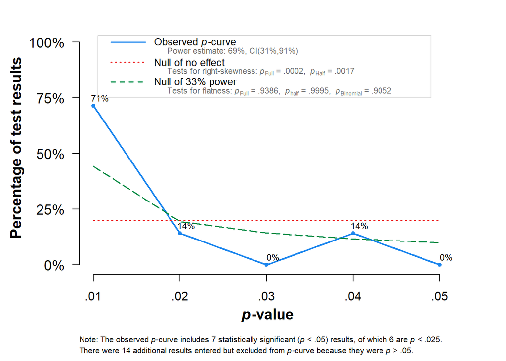

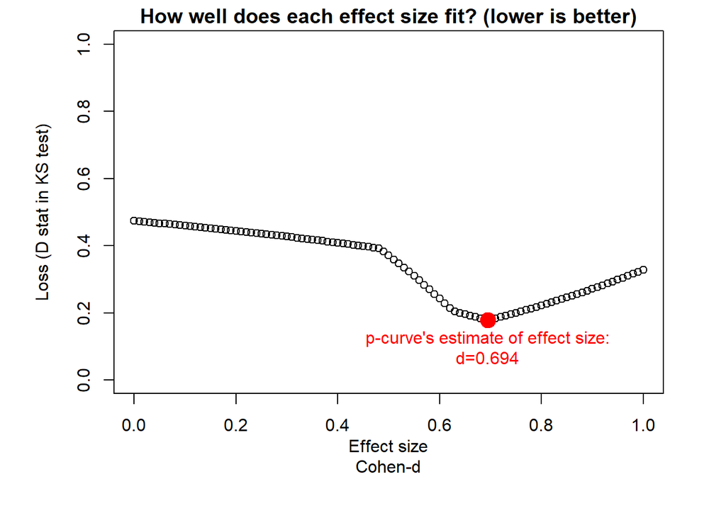

```
## P-curve analysis
##  -----------------------
## - Total number of provided studies: k = 21
## - Total number of p<0.05 studies included into the analysis: k = 7 (33.33%)
## - Total number of studies with p<0.025: k = 6 (28.57%)
##
## Results
##  -----------------------
##                     pBinomial  zFull pFull  zHalf pHalf
## Right-skewness test     0.062 -3.557 0.000 -2.921 0.002
## Flatness test           0.905  1.543 0.939  3.291 1.000
## Note: p-values of 0 or 1 correspond to p<0.001 and p>0.999, respectively.
## Power Estimate: 69% (30.9%-90.9%)
##
## Evidential value
##  -----------------------
## - Evidential value present: yes
## - Evidential value absent/inadequate: no
##
## P-curve's estimate of the true effect size: d=0.694
```

```r
pcurve(ma3,
       effect.estimation = TRUE,
       N = df$nt_ma + df$nc_ma,
       dmin = 0,
       dmax = 1)
```

No indication of bias.

### 1.1.3 Three-parameter selection model

#### 1.1.3.1 Create a `metafor` package meta-analysis object, necessary for the `selmodel` function

```r
ma3_metafor <- rma(yi = smd_ma,
          sei = se_ma,
          data = df,
          method = "DL")
```

#### 1.1.3.2 Fit the selection model

```r
selmodel(ma3_metafor,
         type = "stepfun",
         steps = 0.025)
```

```
##
## Random-Effects Model (k = 21; tau^2 estimator: ML)
##
## tau^2 (estimated amount of total heterogeneity): 0.0485 (SE = 0.0567)
## tau (square root of estimated tau^2 value):      0.2202
##
## Test for Heterogeneity:
## LRT(df = 1) = 1.3287, p-val = 0.2490
##
## Model Results:
##
## estimate      se    zval    pval   ci.lb   ci.ub
##   0.5884  0.1551  3.7936  0.0001  0.2844  0.8925  ***
##
## Test for Selection Model Parameters:
## LRT(df = 1) = 0.0007, p-val = 0.9784
##
## Selection Model Results:
##
##                      k  estimate      se     zval    pval   ci.lb   ci.ub
## 0     < p <= 0.025   7    1.0000     ---      ---     ---     ---     ---
## 0.025 < p <= 1      14    0.9796  0.7453  -0.0273  0.9782  0.0000  2.4405
##
## ---
## Signif. codes:  0 '***' 0.001 '**' 0.01 '*' 0.05 '.' 0.1 ' ' 1
```

No indication of bias.

## 1.2 Outlier/influence diagnostics

### 1.2.1 Leave-one-out analysis

```r
metainf(ma3, pooled = "random")
```

```
## Influential analysis (random effects model)
##
##                      SMD           95%-CI  p-value   tau^2     tau    I^2
## Omitting 1        0.6053 [0.4046; 0.8061] < 0.0001  0.0499  0.2234  25.5%
## Omitting 2        0.6182 [0.4170; 0.8195] < 0.0001  0.0450  0.2122  22.9%
## Omitting 3        0.6024 [0.3985; 0.8063] < 0.0001  0.0534  0.2312  26.6%
## Omitting 4        0.6045 [0.4048; 0.8042] < 0.0001  0.0491  0.2216  25.3%
## Omitting 5        0.6016 [0.3975; 0.8058] < 0.0001  0.0538  0.2319  26.7%
## Omitting 6        0.6394 [0.4509; 0.8279] < 0.0001  0.0217  0.1474  12.1%
## Omitting 7        0.6384 [0.4484; 0.8285] < 0.0001  0.0238  0.1543  13.1%
## Omitting 8        0.5432 [0.3664; 0.7201] < 0.0001  0.0131  0.1145   8.2%
## Omitting 9        0.5676 [0.3689; 0.7664] < 0.0001  0.0441  0.2099  22.9%
## Omitting 10       0.5798 [0.3798; 0.7799] < 0.0001  0.0495  0.2225  25.5%
## Omitting 11       0.5730 [0.3779; 0.7682] < 0.0001  0.0422  0.2054  22.6%
## Omitting 12       0.5825 [0.3810; 0.7840] < 0.0001  0.0515  0.2270  26.2%
## Omitting 13       0.5712 [0.3634; 0.7789] < 0.0001  0.0517  0.2274  24.7%
## Omitting 14       0.6051 [0.4020; 0.8082] < 0.0001  0.0520  0.2281  26.1%
## Omitting 15       0.5923 [0.3886; 0.7960] < 0.0001  0.0547  0.2340  27.3%
## Omitting 16       0.5686 [0.3754; 0.7618] < 0.0001  0.0386  0.1965  21.0%
## Omitting 17       0.5603 [0.3580; 0.7627] < 0.0001  0.0439  0.2095  22.0%
## Omitting 18       0.6032 [0.4015; 0.8050] < 0.0001  0.0516  0.2271  26.2%
## Omitting 19       0.5906 [0.3858; 0.7953] < 0.0001  0.0551  0.2347  27.2%
## Omitting 20       0.5792 [0.3657; 0.7926] < 0.0001  0.0579  0.2407  25.9%
## Omitting 21       0.5953 [0.3908; 0.7999] < 0.0001  0.0550  0.2346  27.3%
##
## Pooled estimate   0.5909 [0.3957; 0.7862] < 0.0001  0.0458  0.2139  23.5%
##
## Details on meta-analytical method:
## - Inverse variance method
## - DerSimonian-Laird estimator for tau^2
```

Removing SMD 8 would reduce the pooled SMD by ~ 0.05 and considerably reduce the variance.

### 1.2.2 Some plots

#### 1.2.2.1 Baujat

```r
outl <- InfluenceAnalysis(ma3, random = TRUE, text.scale = 2)
```

```
## [===========================================================================] DONE
```

```r
png("figures/fig6.png", units = "in", width = 5, height = 5, res = 300)
plot(outl, "baujat")
```

#### 1.2.2.2 Forest plot

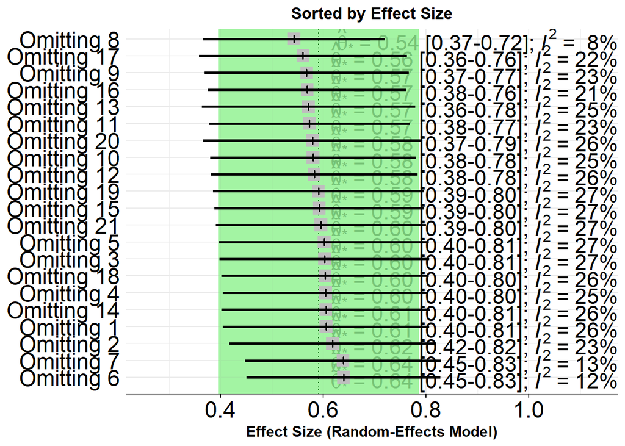

```r
plot(outl, "ES")
```

SMDs 6, 7, and 8 contribute disproportionately to both the variance and the pooled SMD.

### 1.2.3 Run meta-analysis without outliers

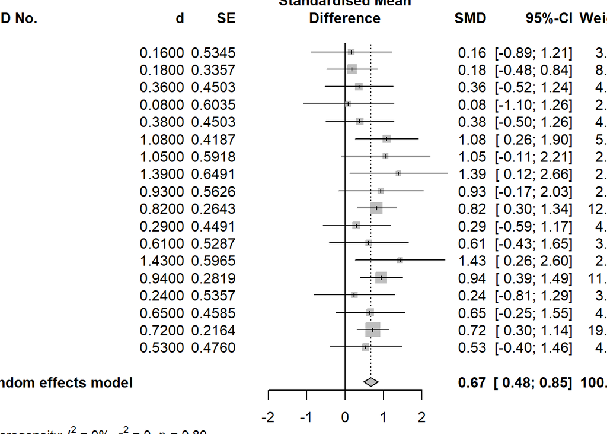

```r
s <- update.meta(ma3, subset = -c(6, 7, 8))
forest.meta(s,

            print.tau2 = TRUE,
            leftlabs = c("SMD No.", "d", "SE"))
```

# 2 Meta-analysis 2

## 2.1 Reproducibility

### 2.1.1 Load dataset & preprocess data

```r
df <- read_excel("data_thesis/Data_ps_raw.xlsx", sheet = "MA2")


# remove characters marking SEs, upper bounds of SE bars, or upper bounds of CIs, to convert to SDs
df[] <- lapply(df, gsub, pattern = '/', replacement = '', fixed = TRUE)
df[] <- lapply(df, gsub, pattern = '*', replacement = '', fixed = TRUE)

# make values numeric
df <- df %>% mutate_at(vars(starts_with('sd')), as.numeric)
df <- df %>% mutate_at(vars(starts_with('mt')), as.numeric)
df <- df %>% mutate_at(vars(starts_with('mc')), as.numeric)
df <- df %>% mutate_at(vars(starts_with('smd')), as.numeric)
df <- df %>% mutate_at(vars(starts_with('n')), as.numeric)
df <- df %>% mutate_at(vars(starts_with('ci')), as.numeric)
df <- df %>% mutate_at(vars(starts_with('p_')), as.numeric)
df <- df %>% mutate_at(vars(starts_with('t_')), as.numeric)
df <- df %>% mutate_at(vars(starts_with('F_')), as.numeric)
df <- df %>% mutate_at(vars(starts_with('se')), as.numeric)

# Convert upper bounds of SE bars extracted from figures to SDs
df[10, "sdc_ps.1"] <- (df[10, "sdc_ps.1"] - df[10, "mc_ps.1"]) * sqrt(13)
df[10, "sdt_ps.1"] <- (df[10, "sdt_ps.1"] - df[10, "mt_ps.1"]) * sqrt(13)

df[11, "sdc_ps.1"] <- (df[11, "sdc_ps.1"] - df[11, "mc_ps.1"]) * sqrt(13)
df[11, "sdt_ps.1"] <- (df[11, "sdt_ps.1"] - df[11, "mt_ps.1"]) * sqrt(13)

df[12, "sdc_ps.1"] <- (df[12, "sdc_ps.1"] - df[12, "mc_ps.1"]) * sqrt(6)
df[12, "sdt_ps.1"] <- (df[12, "sdt_ps.1"] - df[12, "mt_ps.1"]) * sqrt(7)

df[18, "sdc_ps.1"] <- (df[18, "sdc_ps.1"] - df[18, "mc_ps.1"]) * sqrt(13)


# Convert lower bounds of SE bars extracted from figures to SDs
df[13, "sdc_ps.1"] <- (df[13, "sdc_ps.1"] + df[13, "mc_ps.1"]) * sqrt(25)
df[13, "sdt_ps.1"] <- (df[13, "sdt_ps.1"] + df[13, "mt_ps.1"]) * sqrt(25)

df[18, "sdt_ps.1"] <- (df[18, "sdt_ps.1"] + df[18, "mt_ps.1"]) * sqrt(13)
```

```r
# average group sample size
mean((df$nc_ma + df$nt_ma) / 2)
```

```
## [1] 12.175
```

### 2.1.2 Reproduce primary SMDs

#### 2.1.2.1 Between-groups studies which reported sample sizes, means and SDs (SEs/CIs)

```r
#df <- compute_dgs(nt_ps, mt_ps.1, sdt_ps.1, nc_ps, mc_ps.1, sdc_ps.1, data = df, denom = "pooled.sd")
# relocate to facilitate inspection
#df <- df %>% relocate(c(d, g, smd_ma), .after = dv_ps)
```

For PSs that reported means and SDs (no extraction from figure necessary), all reported SMDs were approximated better by Cohen’s $d$s than Hedges’ $g$s. I will thus assume the authors used Cohen’s $d$s:

```r
df <- compute_ds(nt_ps, mt_ps.1, sdt_ps.1, nc_ps, mc_ps.1, sdc_ps.1, data = df, denom = "pooled.sd")

# relocate to facilitate inspection
df <- df %>% relocate(c(id_comparison, d, smd_ma), .after = dv_ps)
```

Reproduced SMDs 6, 7, 9, 12, 14, 15 deviate from the reported ones beyond what would be expected as a result of rounding or differences in how values were extracted from figures. For SMDs 6, 7, 14, and 15, other values could have reasonably been used:

SMDs 6 and 7 had corresponding $p$-values:

```r
# one-tailed p-value + sample sizes to d
p_to_d1(0.925, 6, 5)[1]
```

```
## [1] -0.9529443
```

```r
p_to_d1(0.897, 6, 5)[1]
```

```
## [1] -0.8253498
```

```r
# two-tailed p-value + sample sizes to d
p_to_d2(0.925, 6, 5)[1]
```

```
## [1] 0.05862045
```

```r
p_to_d2(0.897, 6, 5)[1]
```

```
## [1] 0.08062977
```

Since these are even further from the ones based on means and SDs, data extraction was double checked for correctness (see below).

For SMDs 14 and 15, two other sets of means and SDs could have been used:

```r
# Set 2
compute_ds(nt_ps, mt_ps.2, sdt_ps.2, nc_ps, mc_ps.2, sdc_ps.2, data = df, denom = "pooled.sd")$d[[14]]
```

```
## [1] 1.83829
```

```r
compute_ds(nt_ps, mt_ps.2, sdt_ps.2, nc_ps, mc_ps.2, sdc_ps.2, data = df, denom = "pooled.sd")$d[[15]]
```

```
## [1] 1.158407
```

```r
# Set 3
compute_ds(nt_ps, mt_ps.3, sdt_ps.3, nc_ps, mc_ps.3, sdc_ps.3, data = df, denom = "pooled.sd")$d[[14]]
```

```
## [1] 1.428169
```

```r
compute_ds(nt_ps, mt_ps.3, sdt_ps.3, nc_ps, mc_ps.3, sdc_ps.3, data = df, denom = "pooled.sd")$d[[15]]
```

```
## [1] 1.006145
```

Values of set 2 are much closer, but not quite identical.

#### 2.1.2.2 Crossover studies which reported sample sizes, means and SDs (SEs/CIs)

Since the meta-analysts listed the sample size of both the treatment and control group as = $N$ = the number of participants, I use N as the sample size of both groups even though there aren’t two groups:

```r
df2 <- df %>% filter(is.na(nc_ps))
df2 <- compute_ds(n_ps, mt_ps.1, sdt_ps.1, n_ps, mc_ps.1, sdc_ps.1, data = df2, denom = "pooled.sd")
```

Reproduced SMDs 1, 2, 4, 5, 13, 20 deviate from the reported ones beyond what would be expected as a result of rounding or differences in how values were extracted from figures. For SMDs 1, 2, 4, 5, and 20, other values could have reasonably been used:

SMD 1 had two other sets of means and SDs and a corresponding $p$ value:

```r
# Set 2
compute_ds(n_ps, mt_ps.2, sdt_ps.2, n_ps, mc_ps.2, sdc_ps.2, data = df, denom = "pooled.sd")$d[[1]]
```

```
## [1] 0
```

```r
# Set 3
compute_ds(n_ps, mt_ps.3, sdt_ps.3, n_ps, mc_ps.3, sdc_ps.3, data = df, denom = "pooled.sd")$d[[1]]
```

```
## [1] -0.3799707
```

```r
# p-value
p_to_d1(df$p_ps[[1]], df$n_ps[[1]], df$n_ps[[1]])[1]
```

```
## [1] 1.068803
```

```r
p_to_d2(df$p_ps[[1]], df$n_ps[[1]], df$n_ps[[1]])[1]
```

```
## [1] 1.217048
```

The $d$ based on the one-tailed $p$-values is closest.

SMD 2 had a corresponding $p$ value:

```r
p_to_d1(df$p_ps[[2]], df$n_ps[[2]], df$n_ps[[2]])[1]
```

```
## [1] 1.965707
```

```r
p_to_d2(df$p_ps[[2]], df$n_ps[[2]], df$n_ps[[2]])[1]
```

```
## [1] 2.34775
```

Closer.

SMDs 4, 5, and 20 had another set of means and SDs:

```r
compute_ds(n_ps, mt_ps.2, sdt_ps.2, n_ps, mc_ps.2, sdc_ps.2, data = df, denom = "pooled.sd")$d[[4]]
```

```
## [1] -0.5417485
```

```r
compute_ds(n_ps, mt_ps.2, sdt_ps.2, n_ps, mc_ps.2, sdc_ps.2, data = df, denom = "pooled.sd")$d[[5]]
```

```
## [1] 0.3777486
```

```r
compute_ds(n_ps, mt_ps.2, sdt_ps.2, n_ps, mc_ps.2, sdc_ps.2, data = df, denom = "pooled.sd")$d[[20]]
```

```
## [1] 1.409815
```

Nope.

#### 2.1.2.3 Studies which did not report means and/or SDs (SEs/CIs)

For SMD 8, only means were reported. Computing an SMD is thus not possible. For SMD 19 no means or SDs were reported but a potentially suitable $p$-value:

```r
p_to_d1(df$p_ps[[19]], df$n_ps[[19]], df$n_ps[[19]])[1]
```

```
## [1] 0.9459136
```

```r
p_to_d2(df$p_ps[[19]], df$n_ps[[19]], df$n_ps[[19]])[1]
```

```
## [1] 1.11488
```

The one-tailed one is close enough.

For SMD 3, an SMD was reported in the primary study which was close to the one reported in the MA.